# SA_DC_3_CaseStudy

Ketan Bhadoriya

# Analyzing the TV news dataset about weather condition over 7 Years

### Loading the required packages and the Data

```r
library(ggplot2)
library(dplyr)
library(tidytext)
library(tidyr)
library(lubridate)

load(file="climate_text.rda")
```

### Exploring the Data

```r
climate_text
```

```
## # A tibble: 593 x 4
##    station show                                 show_date           text
##    <chr>   <chr>                                <dttm>              <chr>
##  1 MSNBC   Morning Meeting                      2009-09-22 13:00:00 the i~
##  2 MSNBC   Morning Meeting                      2009-10-23 13:00:00 corpo~
##  3 CNN     CNN Newsroom                         2009-12-03 20:00:00 he sa~
##  4 CNN     American Morning                     2009-12-07 11:00:00 espec~
##  5 MSNBC   Morning Meeting                      2009-12-08 14:00:00 lots ~
##  6 MSNBC   Countdown With Keith Olbermann       2009-12-10 06:00:00 so th~
##  7 CNN     Sanjay Gupta MD                      2009-12-12 12:30:00 let m~
##  8 CNN     The Situation Room With Wolf Blitzer 2009-12-16 21:00:00 other~
##  9 MSNBC   Countdown With Keith Olbermann       2009-12-19 01:00:00 let d~
## 10 MSNBC   The Rachel Maddow Show               2010-01-08 04:00:00 you k~
## # ... with 583 more rows
```

```r
head(climate_text)
```

```
## # A tibble: 6 x 4
##   station show                           show_date           text
##   <chr>   <chr>                          <dttm>              <chr>
## 1 MSNBC   Morning Meeting                2009-09-22 13:00:00 the interior~
## 2 MSNBC   Morning Meeting                2009-10-23 13:00:00 corporations~
## 3 CNN     CNN Newsroom                   2009-12-03 20:00:00 he says he w~
## 4 CNN     American Morning               2009-12-07 11:00:00 especially a~
## 5 MSNBC   Morning Meeting                2009-12-08 14:00:00 lots more co~
## 6 MSNBC   Countdown With Keith Olbermann 2009-12-10 06:00:00 so they're c~
```

```r
str(climate_text)
```

```
## Classes 'tbl_df', 'tbl' and 'data.frame':    593 obs. of  4 variables:
##  $ station  : chr  "MSNBC" "MSNBC" "CNN" "CNN" ...
##  $ show     : chr  "Morning Meeting" "Morning Meeting" "CNN Newsroom" "American Morning" ...
##  $ show_date: POSIXct, format: "2009-09-22 13:00:00" "2009-10-23 13:00:00" ...
##  $ text     : chr  "the interior positively oozes class raves car magazine slick and sensuous boasts the washington times the most "| __truncated__ "corporations have withdrawn from the chamber of commerce because of their disagreement with the chamber on the "| __truncated__ "he says he was bump…
```

### Tidying the Data and performing a more EDA

```r
tidy_tv <- climate_text %>%
  # Transforming the non-tidy text data to tidy text data
  unnest_tokens(word,text)

tidy_tv
```

```
## # A tibble: 41,076 x 4
##    station show            show_date           word
##    <chr>   <chr>           <dttm>              <chr>
##  1 MSNBC   Morning Meeting 2009-09-22 13:00:00 the
##  2 MSNBC   Morning Meeting 2009-09-22 13:00:00 interior
##  3 MSNBC   Morning Meeting 2009-09-22 13:00:00 positively
##  4 MSNBC   Morning Meeting 2009-09-22 13:00:00 oozes
##  5 MSNBC   Morning Meeting 2009-09-22 13:00:00 class
##  6 MSNBC   Morning Meeting 2009-09-22 13:00:00 raves
##  7 MSNBC   Morning Meeting 2009-09-22 13:00:00 car
##  8 MSNBC   Morning Meeting 2009-09-22 13:00:00 magazine
##  9 MSNBC   Morning Meeting 2009-09-22 13:00:00 slick
## 10 MSNBC   Morning Meeting 2009-09-22 13:00:00 and
## # ... with 41,066 more rows
```

### Question :what words are most common when discussing climate change on TV news, as well as the total number of words from each station?

```r
tidy_tv %>%
    anti_join(stop_words) %>%
    # Count by word with sort = TRUE
    count(word, sort = TRUE)
```

```
## # A tibble: 3,699 x 2
##    word          n
##    <chr>     <int>
##  1 climate    1627
##  2 change     1615
##  3 people      139
##  4 real        125
##  5 president   112
##  6 global      107
##  7 issue        87
##  8 trump        86
##  9 warming      85
## 10 issues       69
## # ... with 3,689 more rows
```

```r
tidy_tv %>%
    # Count by station
    count(station) %>%
    # Rename the new column station_total
    rename(station_total = n)
```

```
## # A tibble: 3 x 2
##   station  station_total
##   <chr>            <int>
## 1 CNN              10713
## 2 FOX News         10876
## 3 MSNBC            19487
```

Comments: Common words include climate,change,warmig..

### Performing Sentiment Analysis

```r
tv_sentiment <- tidy_tv %>%
  # Group by station
  group_by(station) %>%
  # Define a new column station_total
  mutate(station_total = n()) %>%
  ungroup() %>%
  # Implement sentiment analysis with the NRC lexicon
  inner_join(get_sentiments("nrc"))

tv_sentiment
```

```
## # A tibble: 10,175 x 6
##    station show        show_date           word    station_total sentiment
##    <chr>   <chr>       <dttm>              <chr>           <int> <chr>
##  1 MSNBC   Morning Me~ 2009-09-22 13:00:00 interi~         19487 disgust
##  2 MSNBC   Morning Me~ 2009-09-22 13:00:00 interi~         19487 positive
##  3 MSNBC   Morning Me~ 2009-09-22 13:00:00 interi~         19487 trust
##  4 MSNBC   Morning Me~ 2009-09-22 13:00:00 sensuo~         19487 joy
##  5 MSNBC   Morning Me~ 2009-09-22 13:00:00 sensuo~         19487 positive
##  6 MSNBC   Morning Me~ 2009-09-22 13:00:00 striki~         19487 positive
##  7 MSNBC   Morning Me~ 2009-09-22 13:00:00 join            19487 positive
##  8 MSNBC   Morning Me~ 2009-09-22 13:00:00 presid~         19487 positive
##  9 MSNBC   Morning Me~ 2009-09-22 13:00:00 presid~         19487 trust
## 10 MSNBC   Morning Me~ 2009-09-22 13:00:00 change          19487 fear
## # ... with 10,165 more rows
```

### Question Which stations use the most negative words?

```r
tv_sentiment %>%
  count(station, sentiment, station_total) %>%
  mutate(percent = n / station_total) %>%
  # Filter only for negative words
  filter(sentiment == "negative") %>%
  # Arrange by percent
  arrange(percent)
```

```
## # A tibble: 3 x 5
##   station  sentiment station_total     n percent
##   <chr>    <chr>             <int> <int>   <dbl>
## 1 MSNBC    negative          19487   526  0.0270
## 2 CNN      negative          10713   331  0.0309
## 3 FOX News negative          10876   403  0.0371
```

### Question Which stations use the most positive words?

```r
tv_sentiment %>%
  count(station, sentiment, station_total) %>%
  mutate(percent = n / station_total) %>%
  filter(sentiment == "positive") %>%
  arrange(percent)
```

```
## # A tibble: 3 x 5
##   station  sentiment station_total     n percent
##   <chr>    <chr>             <int> <int>   <dbl>
## 1 FOX News positive          10876   514  0.0473
## 2 CNN      positive          10713   522  0.0487
## 3 MSNBC    positive          19487   953  0.0489
```

**Comments: MSNBC used a low proportion of negative words but a high proportion of positive words, the reverse is true of FOX News, and CNN is middle of the pack.**

### Question : Which words contribute to the sentiment scores?

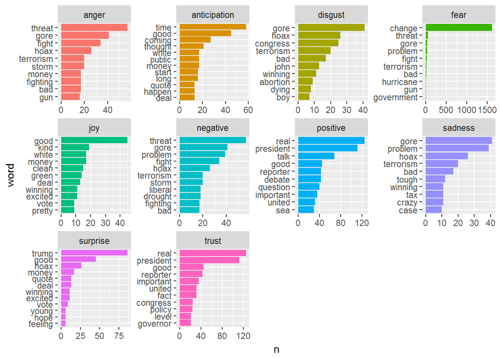

```r
tv_sentiment %>%
  # Count by word and sentiment
  count(word, sentiment) %>%
  # Group by sentiment
  group_by(sentiment) %>%
  # Take the top 10 words for each sentiment ordered by n
  top_n(10, n) %>%
  ungroup() %>%
  mutate(word = reorder(word, n)) %>%
  # Set up the plot with aes()
  ggplot(aes(word, n, fill = sentiment)) +
  geom_col(show.legend = FALSE) +
  facet_wrap(~ sentiment, scales = "free") +
  coord_flip()
```

### Which negative words did each station use when talking about climate change on the air?

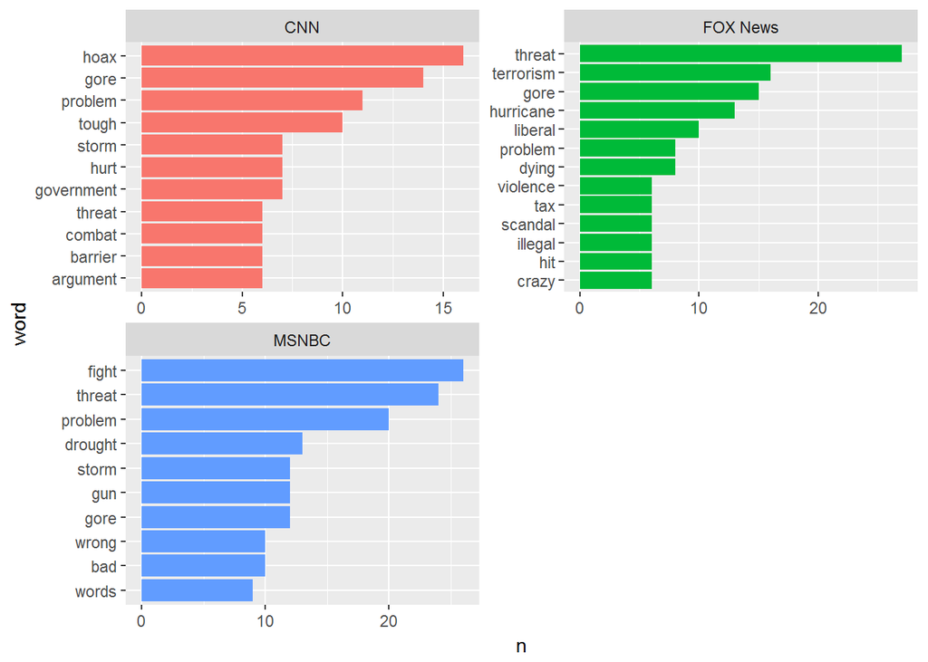

```r
tv_sentiment %>%
    # Filter for only negative words
    filter(sentiment=="negative") %>%
    # Count by word and station
    count(word,station) %>%
    # Group by station
    group_by(station) %>%
    # Take the top 10 words for each station
    top_n(10,n) %>%
    ungroup() %>%
    mutate(word = reorder(paste(word, station, sep = "__"), n)) %>%
    # Set up the plot with aes()
    ggplot(aes(word,n,fill=station)) +
    geom_col(show.legend = FALSE) +
    scale_x_discrete(labels = function(x) gsub("__.+$", "", x)) +
    facet_wrap(~ station, nrow = 2, scales = "free") +
    coord_flip()
```

**Comments : Some words, like “threat” are used by all three stations but some word choices are quite different. FOX News talks about terrorism and hurricanes, while CNN discusses hoaxes.**

### Question : Are TV news stations using more negative words as time passes?

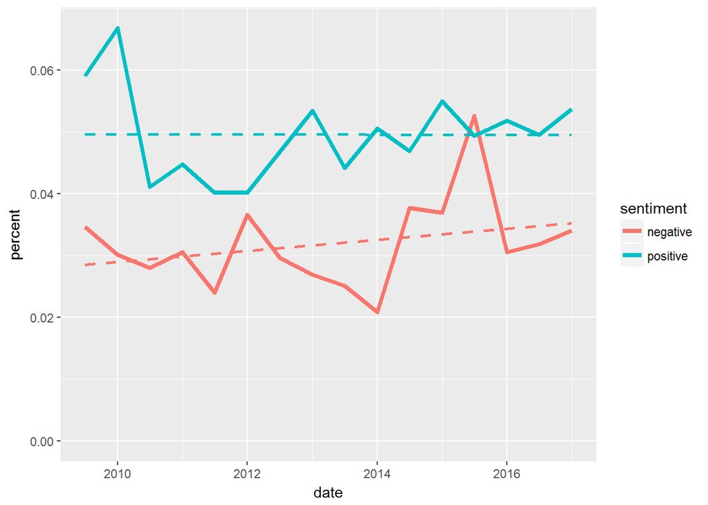

```r
sentiment_by_time <- tidy_tv %>%
    # Define a new column using floor_date()
    mutate(date = floor_date(show_date, unit = "6 months")) %>%
    # Group by date
    group_by(date) %>%
    mutate(total_words = n()) %>%
    ungroup() %>%
    # Implement sentiment analysis using the NRC lexicon
    inner_join(get_sentiments("nrc"))

sentiment_by_time %>%
    # Filter for positive and negative words
    filter(sentiment %in% c("positive", "negative")) %>%
    # Count by date, sentiment, and total_words
    count(date, sentiment, total_words) %>%
    ungroup() %>%
    mutate(percent = n / total_words) %>%
    # Set up the plot with aes()
    ggplot(aes(date, percent, color = sentiment)) +
    geom_line(size = 1.5) +
    geom_smooth(method = "lm", se = FALSE, lty = 2) +
    expand_limits(y = 0)
```

**Comments : The proportion of positive words looks flat, and the proportion of negative words may be increasing.**

### Word Changes Over Time

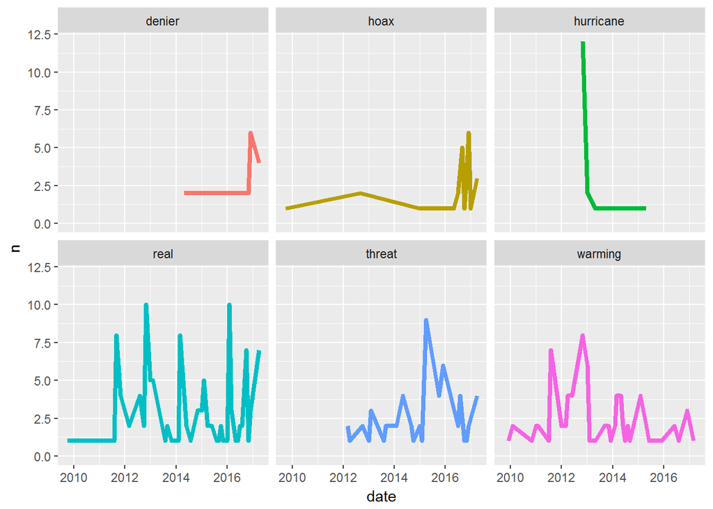

```r
tidy_tv %>%
    # Define a new column that rounds each date to the nearest 1 month
    mutate(date = floor_date(show_date, unit = "1 month")) %>%
    filter(word %in% c("threat", "hoax", "denier",
                       "real", "warming", "hurricane")) %>%
    # Count by date and word
    count(date, word) %>%
    ungroup() %>%
    # Set up your plot with aes()
    ggplot(aes(date, n, color = word)) +
    # Make facets by word
    facet_wrap(~word) +
    geom_line(size = 1.5, show.legend = FALSE) +
    expand_limits(y = 0)
```